# Econometric with R

Uma tradução barata

Nabil Murtadha

# Revisando conceitos estatísticos

1. Estimativa de parâmetros desconhecidos da população
2. Testando hipóteses
3. Intervalos de confiança

```r
library(dplyr)
library(MASS)
library(readxl)
```

### Estimativa da média da população

*Estimadores* são funções de dados de uma amostra da populção e *Estimativas* são valores numéricos calculados por estimadores com base na amostra.

- *Estimadores* = Variáveis aleatórias
- *Estimativas* = Números *não* aleatórios.

Vamos supor $Y = horas.ganhas$ para graduados do ensino superior e estamos interesado em estimar a média.

Pode ser que, $\bar{Y} = \frac{1}{N}\sum_{k = 1}^{N} Y_i$ é o estimador e $\bar{Y}$ é a estimativa. Para sabermos se a função é um bom estimador podemos testar a distribuição da população. Vamos testar a estimativa com a população hipotética abaixo

```r
curve(dchisq(x, df = 12),
      from = 0,
      to = 40,
      ylab = "densidade",
      xlab = "Horas ganho em Euro")
```

[output not shown]

Agora vamos supor que a $n = 100$ observações. Vamos extrair a primeira observação ($Y_i$) e a média.

```r
# reprodutibilidade
set.seed(1)

# amostra do gráfico acima
amostra <- rchisq(n = 100, df = 12)

amostra_1 <- amostra[1] %>% print()
```

[output not shown]

Temos que a primeira observação é $8.26$ e a média da amostra é $12$, não tão distante e ainda mais sem levar em conta a variação da população. Que é $Var(Y_1) = Var(Y) = 2*12 = 24$

O que é um bom estimador? Um bom estimador é aquele que não contém viés, é consistente e eficiente.

**Não enviesado** = média da amostra é do estimador é igual a média da amostra. $E(\hat{\mu}_Y) = \mu_Y$

**Consistencia** = Quanto maior a amostra, mais próxima queremos que que o estimativa se aproxime da média populacional. $\hat{\mu}_Y \rightarrow \mu_Y$

**Variância e Eficiêcia** = Quanto menor $Var(\hat{\mu_Y})$ melhor o estimador.

# Regressão Linear com um regressor

Apenas uma variável explicativa = $X_1$. Como exemplo usaremos a relação professor-estudante como $X_1$, e como isso afeta a performace dos estudantes representado por $Y$. Conseguiremos não apenas determinar o impacto mas também aprender sobre o sinal e a quantidade do efeito.

### Regressão linear simples.

Criando os dados hipotéticos

```r
# criando a amostra
EPR <- c(15,17,19,20,22,23.5,25)
nota <- c(680, 640, 670, 660, 630, 660, 635)
```

Na regressão simples assume-se que a relação entre a variável dependente e independente é linar de modo que:

$Y = b \cdot X + a$

Por enquanto, vamos supor que a relação seja descrita da função abaixo:

$nota = 713 - 3\times RAP$

Vamos esboçar um gráfico com os valores de `nota` e `RAP` nos eixos y e x. E também traçar a linha da função acima.

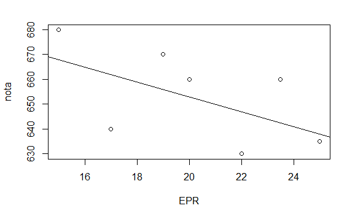

```r
# dados
plot(nota ~ EPR)

# função
abline(a = 713, b = -3) # intercepto e inclinação
```

Vimos que a função não passa por nenhum ponto do gráfico. Isso ocorre devido a aleatorização, dificilmente apenas um fator influencie totalmente a variável dependente, existem outros fatores que estão fora da análise que podem contribuir para a nota média da turma.

$nota = \beta_0 + \beta_1 \times RAP\ + outros fatores$

Atribuiremos a diferença entre o ponto e a reta como termo de erro ($u$) e fórmula completa fica:

$Y_i = \beta_0 + \beta_1X_i\ + u_i$

Na equação acima, $\beta_0$ é o intercepto, $\beta_1$ é a inclinação e $u_i$ é o termo de erro.

### Estimando os coeficientes do modelo de regressão linear

Carregando a base de dados.

```r
library(AER)

#carregando dados para o exemplo
data("CASchools")
```

Após o carregamento do `data.frame` vamos criar as variáveis de interesse a partir disso

```r
# relacao aluno professor
CASchools$RAP <- CASchools$students/CASchools$teachers

# media das notas médias de matematica e leitura
CASchools$nota<- (CASchools$read + CASchools$math)/2

# verificando as novas variaveis
head(CASchools)
```

[output not shown]

Agora vamos guardar as médias, desvios pedoes e os quartils das duas variáveis

```r
# criando os vetores de media
m_RAP <- mean(CASchools$RAP)
m_nota <- mean(CASchools$nota)

# criando os vetores de desvio padrão
dp_RAP <- sd(CASchools$RAP)
dp_nota <- sd(CASchools$nota)

# classificando os quantils/porcentagens
quantil <- c(0.10, 0.25, 0.4, 0.5, 0.6, 0.75, 0.9)
quant_RAP <- quantile(CASchools$RAP, quantil)
quant_nota <- quantile(CASchools$nota, quantil)

# grando a matrix/data frame com os vetores acima
DistributionSummary <- data.frame(Media = c(m_RAP, m_nota),
                                  DesvioPadrão = c(dp_RAP, dp_nota),
                                  quantil = rbind(quant_RAP, quant_nota))

DistributionSummary
```

[output not shown]

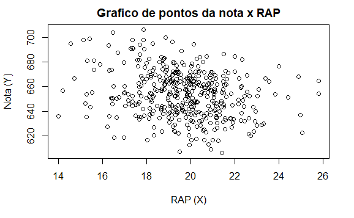

```r
plot(nota ~ RAP,
     data = CASchools,
     main = "Grafico de pontos da nota x RAP",
     xlab = "RAP (X)",
     ylab = "Nota (Y)")
```

O gráfico acima mostra que os pontos estão bem diversos e existe uma possível correlação negativa entre as variáveis, ou seja, quanto menor o tamanho da turma maior o rendimento dela.

Verificando a correlação temos:

```r
# correlação
cor(CASchools$RAP, CASchools$nota)
```

```
[1] -0.2263627
```

Assim como o gráfico sugere, o valor da correlação é negativa porém fraca no valor de `-0.23`. O desafio agora é buscar qual função linear melhor se ajusta a distribuição dos pontos acima. Utilizaremos a técnica dos *Minimos Quadrados Ordinarios*(MQO/OLS)

**Mínimos Quadrados Ordinários**